# A roadmap for plant mutation detection tools with variable sequencing depth and allele frequency using two reproducible pipelines

2021-06-28

**Running title: plant mutation detection tools**

Authors (**alphabetic**):

- Myriam Heuertz
  - heuertzm@gmail.com
  - orcid.org/0000-0002-6322-3645
  - Univ. Bordeaux, INRAE, BIOGECO, 69 route d’Arcachon, 33610 Cestas France
- Thibault Leroy
  - orcid.org/0000-0003-2259-9723
  - Department of Botany and Biodiversity Research, University of Vienna, Rennweg 14, A-1030 Vienna, Austria
- Sylvain Schmitt
  - Corresponding author
  - sylvain.m.schmitt@gmail.com
  - orcid.org/0000-0001-7759-7106
  - CNRS, UMR EcoFoG (Agroparistech, Cirad, INRAE, Université des Antilles, Université de la Guyane), Campus Agronomique, 97310 Kourou, French Guiana
- Niklas Tysklind
  - Niklas.Tysklind@ecofog.gf
  - INRAE, UMR EcoFoG (Agroparistech, CNRS, Cirad, Université des Antilles, Université de la Guyane), Campus Agronomique, 97310 Kourou, French Guiana

# Abstract

# Introduction

# Material and Methods

## Generation of mutations

## Detection of mutations

## Virtual experiment

## Oak data reanalyses

# Results

# Discussion

# Acknowledgements

# References

# Authors’ contributions

All authors conceived the ideas; SS developed the pipelines; SS and TL realized the virtual experiment; SS and TL analyzed outputs; SS and TL led the writing of the manuscript. All authors contributed critically to the drafts and gave final approval for publication.

# Data Accessibility

`generateMutations` and `detectMutations` pipelines are available on GitHub (https://github.com/sylvainschmitt/generateMutations and https://github.com/sylvainschmitt/detectMutations). Reanalyzed reads and corresponding genomes were extracted from GenBank under accession BioProject PRJNA327502 and from European Nucleotide Archive under project accession code PRJEB8388.

# Tables and Figures

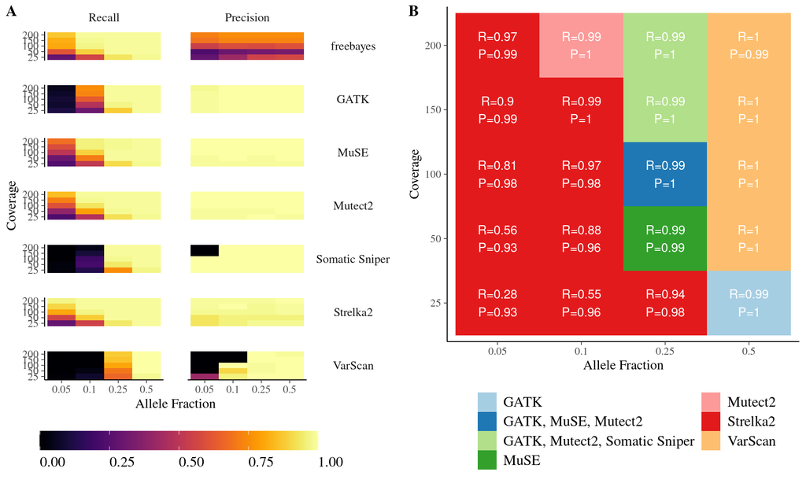